# DNA Methylation

Gianluca

2025-05-17

```r
setwd("C:/Users/gianl/Desktop/ETH/BiologyMsc/Spring Semester Material/BARGE/Assignments/week11")

suppressPackageStartupMessages({
  library(epiwraps)
  library(ggplot2)
  library(ensembldb)
  library(edgeR)
  library(rtracklayer)
  library(BiocParallel)
  library(bsseq)
  library(DMRcate)
  library(GenomicRanges)
  library(rGREAT)
})
unzip("w11_practical.zip")
```

# Genes in Top 5 Differentially Methylated Regions heatmap

```r
# Getting BSseq data
bs <- readRDS("ESC_astrocytes_BSseq.rds")
# remove CpGs that have 0 coverage in some samples:
bs <- bs[rowSums(assay(bs,"Cov")>0)==ncol(bs),]

design <- model.matrix(~celltype, data=pData(bs))
# adapt the design for methylation data:
methdesign <- modelMatrixMeth(design)

bs <- BSmooth(bs, BPPARAM=MulticoreParam(4, progress=TRUE))
```

[output not shown]

[output not shown]

[output not shown]

[output not shown]

[output not shown]

[output not shown]

[output not shown]

[output not shown]

[output not shown]

[output not shown]

[output not shown]

[output not shown]

[output not shown]

[output not shown]

[output not shown]

[output not shown]

[output not shown]

[output not shown]

[output not shown]

[output not shown]

[output not shown]

[output not shown]

[output not shown]

[output not shown]

[output not shown]

[output cut: 23 more lines]

[output not shown]

[output not shown]

[output not shown]

[output not shown]

[output not shown]

[output not shown]

[output not shown]

[output not shown]

[output not shown]

[output not shown]

[output not shown]

[output not shown]

[output cut: 13 more lines]

[output not shown]

[output not shown]

[output not shown]

[output not shown]

[output not shown]

[output not shown]

[output not shown]

[output not shown]

[output not shown]

[output not shown]

[output not shown]

[output not shown]

[output not shown]

[output not shown]

[output not shown]

[output not shown]

[output not shown]

[output not shown]

[output not shown]

[output not shown]

[output not shown]

[output not shown]

[output not shown]

[output not shown]

[output not shown]

[output not shown]

[output not shown]

[output not shown]

[output not shown]

[output not shown]

[output not shown]

[output not shown]

[output not shown]

[output not shown]

[output not shown]

[output not shown]

[output not shown]

[output not shown]

[output not shown]

[output not shown]

[output not shown]

[output not shown]

[output not shown]

[output not shown]

[output not shown]

[output not shown]

[output not shown]

[output not shown]

[output not shown]

[output not shown]

[output not shown]

[output not shown]

[output not shown]

[output not shown]

[output not shown]

[output not shown]

[output not shown]

[output not shown]

[output not shown]

[output not shown]

[output not shown]

[output not shown]

[output not shown]

[output not shown]

[output not shown]

[output not shown]

[output not shown]

[output not shown]

[output not shown]

[output not shown]

[output not shown]

[output not shown]

[output not shown]

[output not shown]

[output not shown]

[output not shown]

[output not shown]

[output not shown]

[output not shown]

[output not shown]

[output not shown]

[output not shown]

[output not shown]

[output not shown]

[output not shown]

[output not shown]

```r
# Find genes in top 5 DMR
dmr <- readRDS("dmr.rds")
chr1_regions <- dmr[seqnames(dmr)=="chr1"]
ordered_chr1 <- chr1_regions[order(mcols(chr1_regions)$meandiff, decreasing = TRUE)]
top5 <- ordered_chr1[1:5]
# We have a total of 6 genes in the top 5 DMR regions of chr1 where the most enriched region shows no overlapping genes
# The genes symbols are MAP7D1, ELF3, RP11-465N4.4, RP11-544M22.13, TSTD1, SEMA6C)

# Genes in chr1
genes <- readRDS("hg19_chr1_genes.rds")

# Check if these genes are present also in the hg19_chr1 list
genes_to_check <- c("MAP7D1", "ELF3", "RP11-465N4.4", "RP11-544M22.13", "TSTD1", "SEMA6C")
genes_to_check %in% genes$symbol
```

```
## [1]  TRUE  TRUE FALSE FALSE  TRUE  TRUE
```

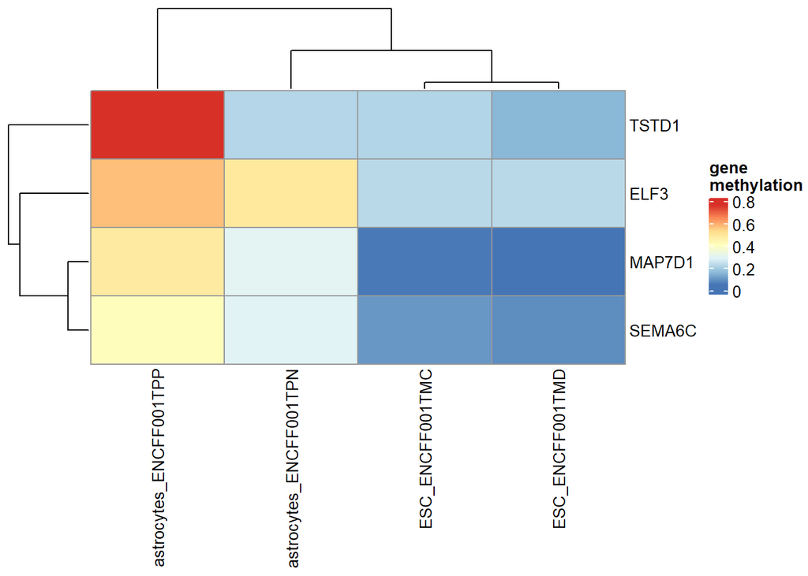

```r
# "RP11-465N4.4" and "RP11-544M22.13" are not shared so I remove them from the list

# genes in top 5 regions
topgenes <- genes[c("MAP7D1", "ELF3", "TSTD1", "SEMA6C")]

# Get methylation for the genes
metGen <- bsseq::getMeth(bs, regions = topgenes, what = "perRegion")
colnames(metGen) <- colnames(bs)
rownames(metGen) <- topgenes$symbol

# heatmap plot
pheatmap(metGen, name="gene\nmethylation")
```

# Enrichment Analysis of Significant DMRs

```r
# per default great compares to the entire genome if no background is specified

res <- great(dmr, gene_sets = "GO:BP", tss_source = "hg19", cores = 2)
```

```
## * TSS source: TxDb.
```

```
## * check whether TxDb package 'TxDb.Hsapiens.UCSC.hg19.knownGene' is installed.
```

```
## * gene ID type in the extended TSS is 'Entrez Gene ID'.
```

```
## * restrict chromosomes to 'chr1, chr2, chr3, chr4, chr5, chr6, chr7, chr8, chr9, chr10,
##     chr11, chr12, chr13, chr14, chr15, chr16, chr17, chr18, chr19, chr20, chr21, chr22, chrX,
##     chrY, chrM'.
```

```
## * 18561/23033 protein-coding genes left.
```

```
## * update seqinfo to the selected chromosomes.
```

```
## * TSS extension mode is 'basalPlusExt'.
```

```
## * construct the basal domains by extending 5000bp to upstream and 1000bp to downsteram of TSS.
```

```
## * calculate distances to neighbour regions.
```

```
## * extend to both sides until reaching the neighbour genes or to the maximal extension.
```

```
## * use GO:BP ontology with 15413 gene sets (source: org.Hs.eg.db).
```

```
## * check gene ID type in `gene_sets` and in `extended_tss`.
```

```
## * use whole genome as background.
```

```
## * remove excluded regions from background.
```

```
## * overlap `gr` to background regions (based on midpoint).
```

```
## * in total 2797 `gr`.
```

```
## * overlap extended TSS to background regions.
```

```
## * check which genes are in the gene sets.
```

```
## * only take gene sets with size >= 5.
```

```
## * in total 9094 gene sets.
```

```
## * overlap `gr` to every extended TSS.
```

```
## * perform binomial test for each biological term.
```

```r
bp <- getEnrichmentTables(res)
head(bp)
```

```
##           id                                                description
## 1 GO:0035095                            behavioral response to nicotine
## 2 GO:0060482                                 lobar bronchus development
## 3 GO:0072044                                collecting duct development
## 4 GO:0071332                     cellular response to fructose stimulus
## 5 GO:0030812        negative regulation of nucleotide catabolic process
## 6 GO:0033122 negative regulation of purine nucleotide catabolic process
##   genome_fraction observed_region_hits fold_enrichment      p_value
## 1    0.0003218835                   20       22.214618 0.000000e+00
## 2    0.0003511700                   20       20.361985 0.000000e+00
## 3    0.0020743648                   41        7.066531 0.000000e+00
## 4    0.0002106800                   15       25.455141 2.220446e-16
## 5    0.0010493592                   26        8.858429 2.220446e-16
## 6    0.0010493592                   26        8.858429 2.220446e-16
##       p_adjust mean_tss_dist observed_gene_hits gene_set_size
## 1 0.000000e+00         76216                  4             8
## 2 0.000000e+00         74106                  3             6
## 3 0.000000e+00         91208                 11            15
## 4 1.689125e-13         80290                  3             5
## 5 1.689125e-13        131776                  5            18
## 6 1.689125e-13        131776                  5            18
##   fold_enrichment_hyper p_value_hyper p_adjust_hyper
## 1              2.965964  3.183578e-02    0.168514425
## 2              2.965964  6.411465e-02    0.245972997
## 3              4.350080  2.155427e-06    0.000110362
## 4              3.559156  3.658979e-02    0.184159375
## 5              1.647758  1.741086e-01    0.423459605
## 6              1.647758  1.741086e-01    0.423459605
```

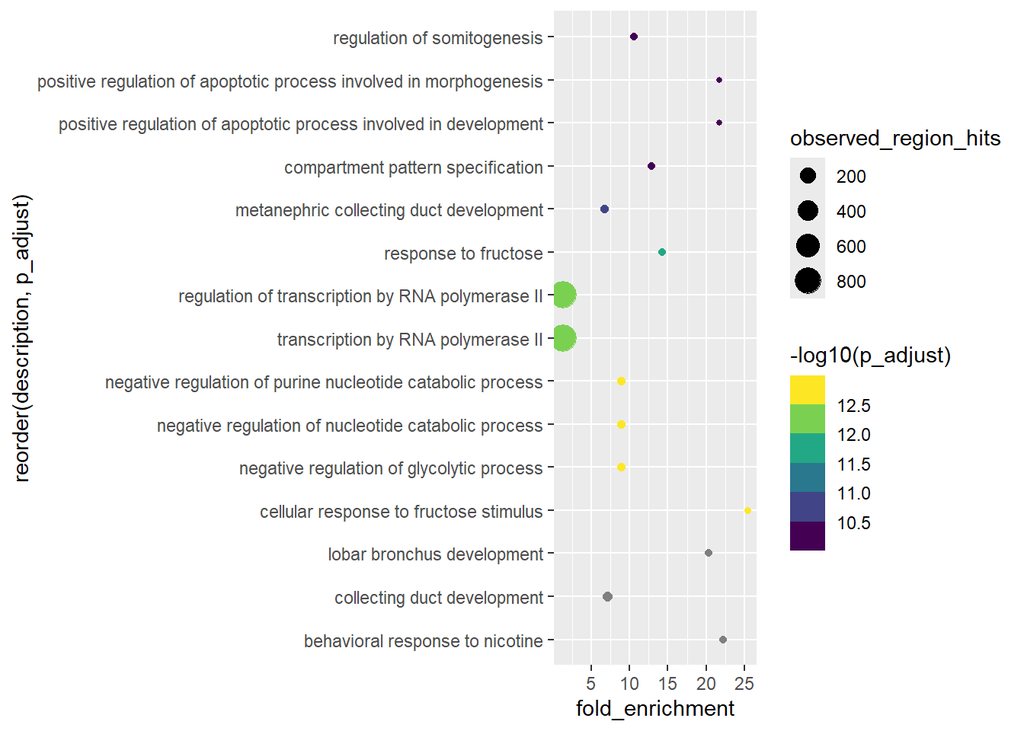

```r
# Plotting
ggplot(head(bp,15), aes(fold_enrichment, reorder(description, p_adjust),
                        size=observed_region_hits, color= -log10(p_adjust)))+
  geom_point()+scale_color_viridis_b()
```

# Comment of enrichment analysis

With this enrichment analysis the genes present at differentially methylated regions on chromosome 1 are compared to all the genes present in the entire genome. Each gene is grouped into the correspondent biological process based on Gene Onthology terms. The results from the enrichment analysis is not entirely coherent with the expectations of compairing astrocytes to embryonic stem cells. The assumption would be that biological processes related to stereotypical astrocyte functions would be enriched, such as neuromodulator release or neuronal maintenance. The reason for this might be given by the fact that genes and functions are not uniformally distributed among chromosomes. Hence, there might be biases for certain functions that are more represented at the specific chromosome then the whole genome.

```r
sign_dmrs <- dmr[dmr$HMFDR <= 10^(-12.5) & (dmr$meandiff >= 2.5 | dmr$meandiff <= -2.5),]
res2 <- great(sign_dmrs, background= dmr, gene_sets = "GO:BP", tss_source = "hg19", cores = 2)
```

```
## * TSS source: TxDb.
```

```
## * extended_tss is already cached, directly use it.
```

```
## * use GO:BP ontology with 15413 gene sets (source: org.Hs.eg.db).
```

```
## * check gene ID type in `gene_sets` and in `extended_tss`.
```

```
## * use self-defined background regions.
```

```
## * remove excluded regions from background.
```

```
## * overlap `gr` to background regions (based on midpoint).
```

```
## * in total 175 `gr`.
```

```
## * overlap extended TSS to background regions.
```

```
## * check which genes are in the gene sets.
```

```
## * only take gene sets with size >= 5.
```

```
## * in total 4359 gene sets.
```

```
## * overlap `gr` to every extended TSS.
```

```
## * perform binomial test for each biological term.
```

```r
bp2 <- getEnrichmentTables(res2)
head(bp2)
```

```
##            id                                              description
## 1  GO:0006954                                    inflammatory response
## 2  GO:0006952                                         defense response
## 5  GO:0010467                                          gene expression
## 9  GO:1902532 negative regulation of intracellular signal transduction
## 10 GO:1905953                negative regulation of lipid localization
## 12 GO:0045776                    negative regulation of blood pressure
##    genome_fraction observed_region_hits fold_enrichment      p_value  p_adjust
## 1      0.069076433                   26        2.150827 0.0001889426 0.2114268
## 2      0.117800196                   36        1.746298 0.0006060336 0.2226549
## 5      0.501686901                  109        1.241526 0.0008320121 0.2226549
## 9      0.061865343                   22        2.032063 0.0012771095 0.2226549
## 10     0.012217621                    8        3.741668 0.0015213431 0.2226549
## 12     0.009651153                    7        4.144583 0.0016864588 0.2226549
##    mean_tss_dist observed_gene_hits gene_set_size fold_enrichment_hyper
## 1         117540                 22           144              1.754730
## 2          98219                 32           282              1.303320
## 5         105839                118          1087              1.246817
## 9         111447                 17           126              1.549632
## 10         87311                  5            10              5.742754
## 12         85532                  4            10              4.594203
##    p_value_hyper p_adjust_hyper
## 1   0.0057166732      0.2493588
## 2   0.0657477323      0.4020312
## 5   0.0013738797      0.2438167
## 9   0.0433604585      0.3724080
## 10  0.0008435422      0.2359809
## 12  0.0077410407      0.2706945
```

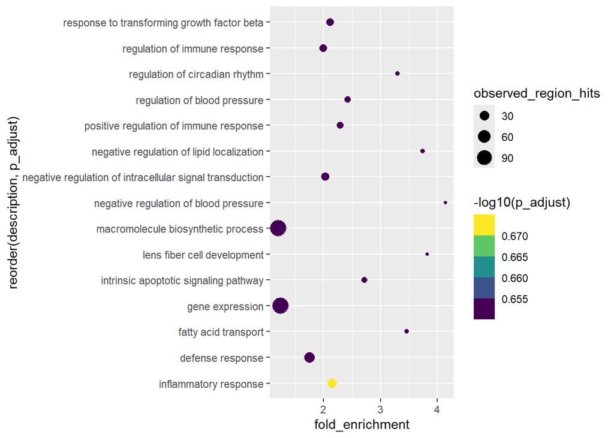

```r
# Plotting
ggplot(head(bp2,15), aes(fold_enrichment, reorder(description, p_adjust),
                        size=observed_region_hits, color= -log10(p_adjust)))+
  geom_point()+scale_color_viridis_b()
```